# BGC and GCF Clustering

Two tools were used to detect biosynthetic gene clusters in the 458 *streptococcus mutans* genomes.

## BGC Clustering using GECCO and antiSMASH

### Biosynthetic classes

The two BGC detection tools GECCO and antiSMASH found 2849 and 3708 respectively and assigned them into the classes ribosomally synthesised and post-translationally modified peptides (RiPPs), non- ribosomal peptides (NRPs), and polyketides (PKS). The majority of BGCs were identified as RiPPs.

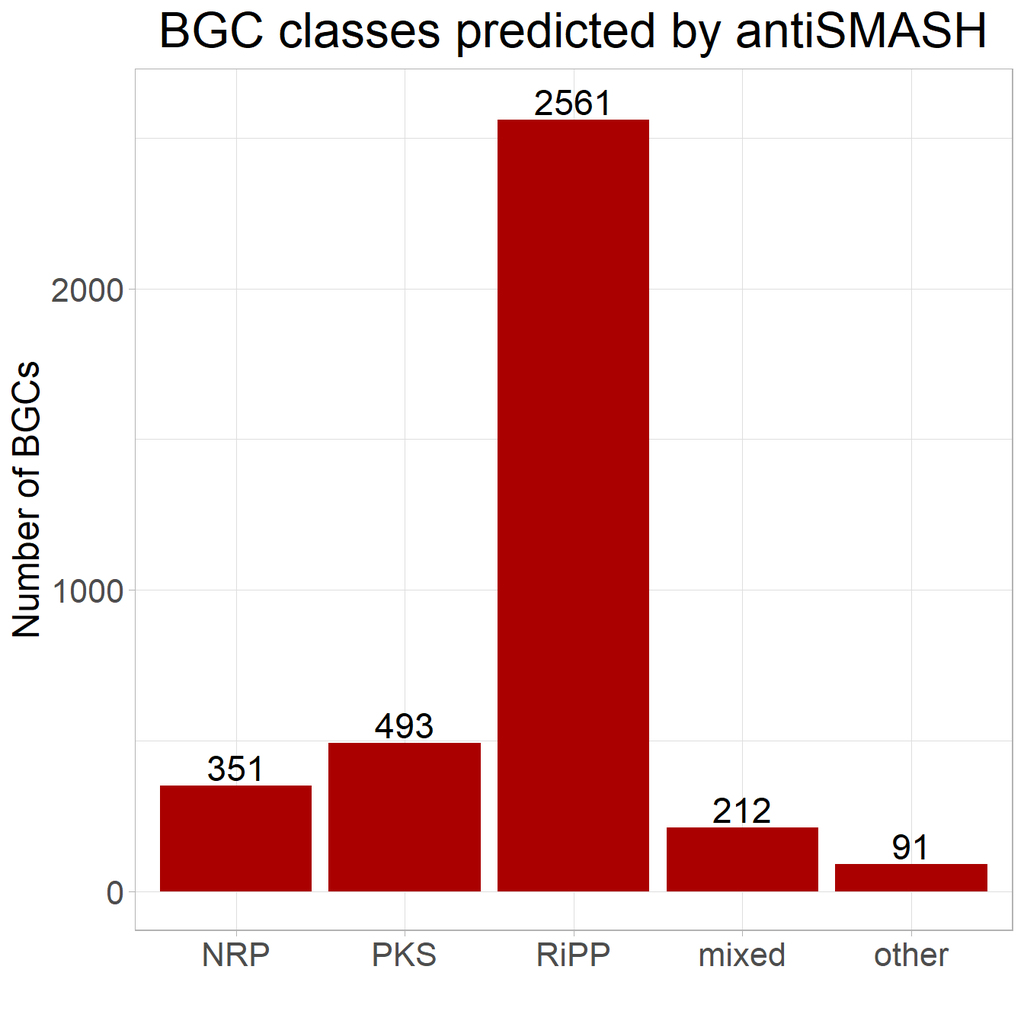

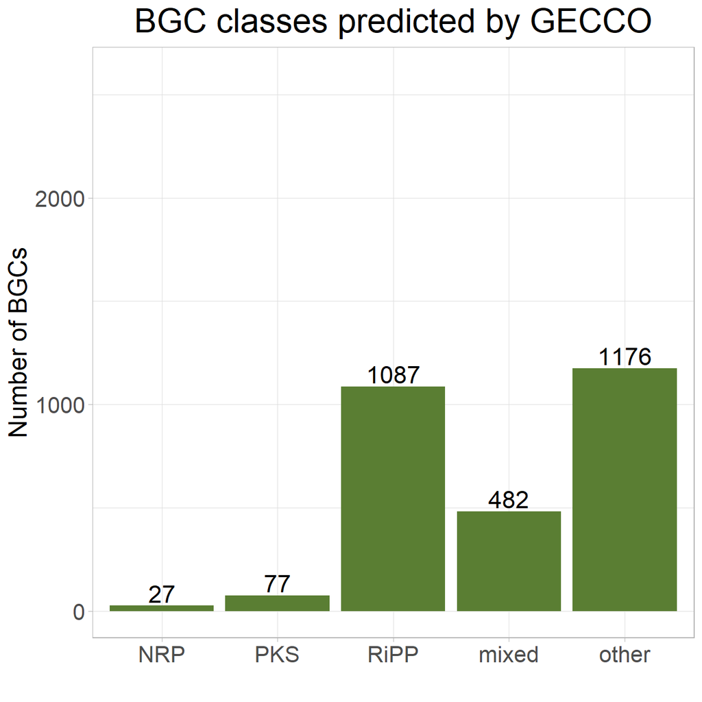

### Number of BGCs per genome

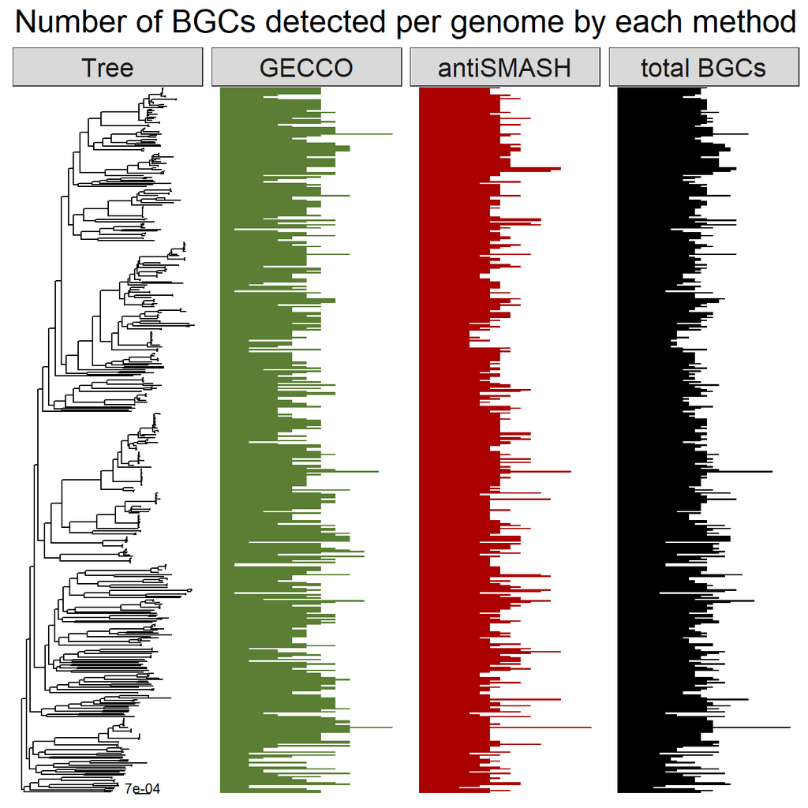

The number of of BGCs is relatively evenly distributed across all genomes. Some have visibly more than others, but there are no extreme outliers. Both methods also seem to follow the same trends, meaning if for example GECCO indentifies a lot of BGCs, so does antiSMASH.

### Aggregation with MIBiG BGCs

To cluster the BGCs furhter into gene cluster families (GCFs), 2502 validated BGCs from the MIBiG database were included for comparison purposes.

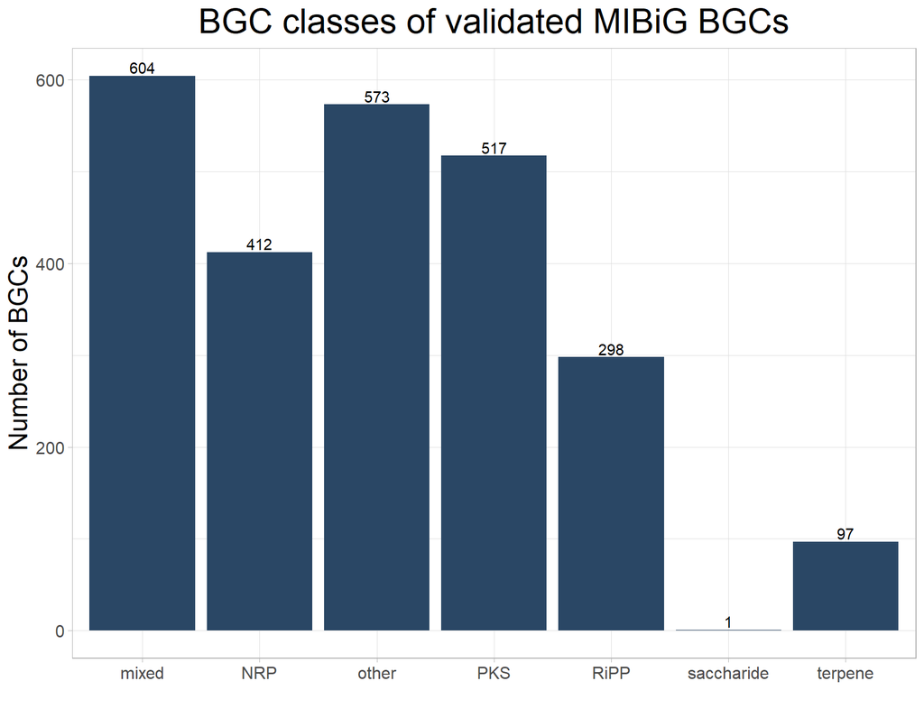

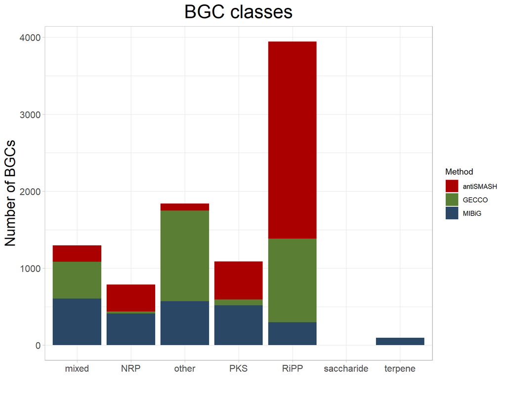

## Gene cluster families

The set of 9059 BGCs were clustered into 1640 GCFs.

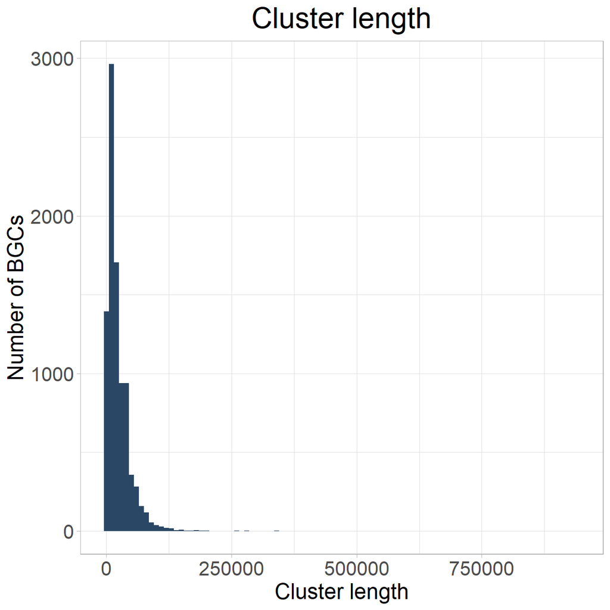

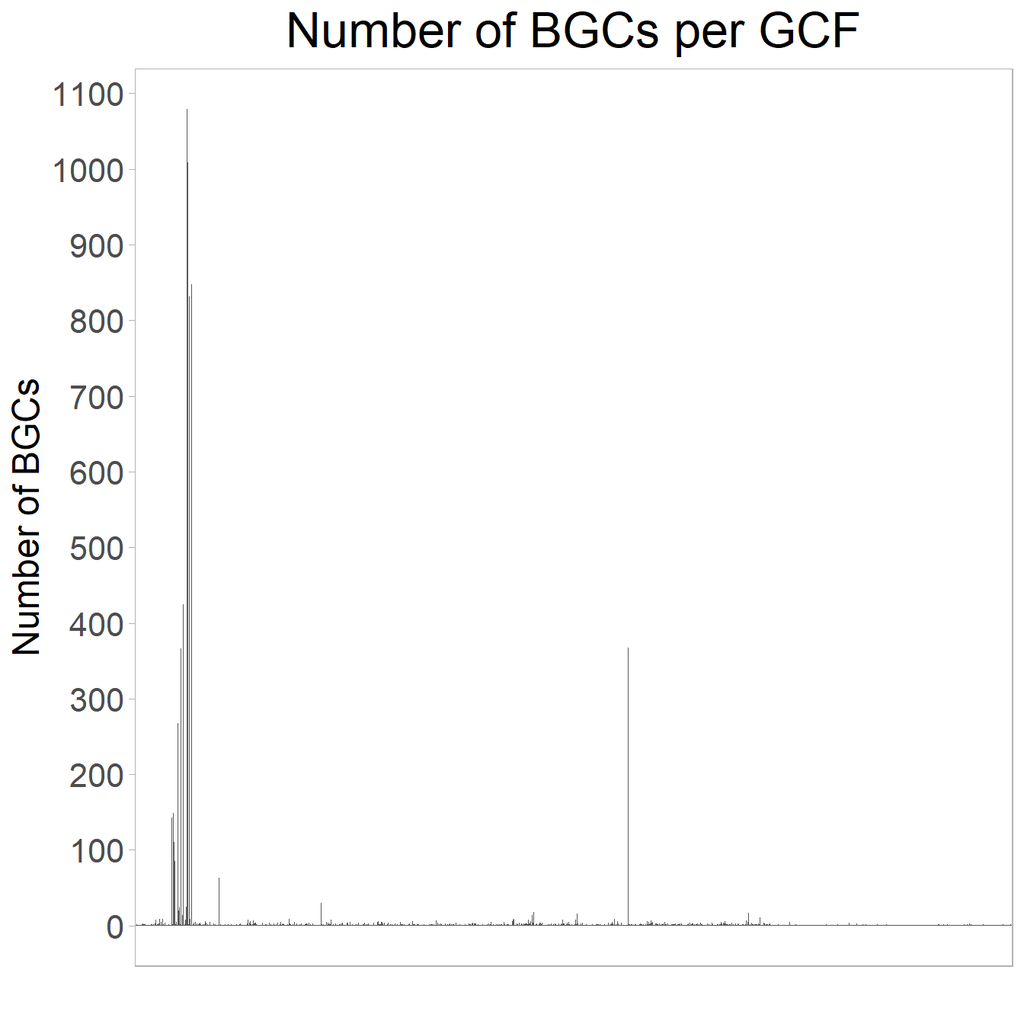

Cluster length describes how many base pairs the GCF is on average. Most GCFs are around 20,000 bp. The distribution of BGCs per GCF shows that most (1613) GCFs contain less than 10 BGCs with only 13 containing more than 100 and 2 over 1000.

| gcf_id | cluster_count |
| --- | --- |
| GCF0000075 | 110 |
| GCF0000070 | 143 |
| GCF0000073 | 149 |
| GCF0000092 | 264 |
| GCF0000082 | 268 |
| GCF0000087 | 285 |
| GCF0000088 | 366 |
| GCF0000923 | 367 |
| GCF0000091 | 425 |
| GCF0000103 | 832 |
| GCF0000107 | 848 |
| GCF0000100 | 1009 |
| GCF0000099 | 1079 |